# Multiverse Analysis in R

Workshop

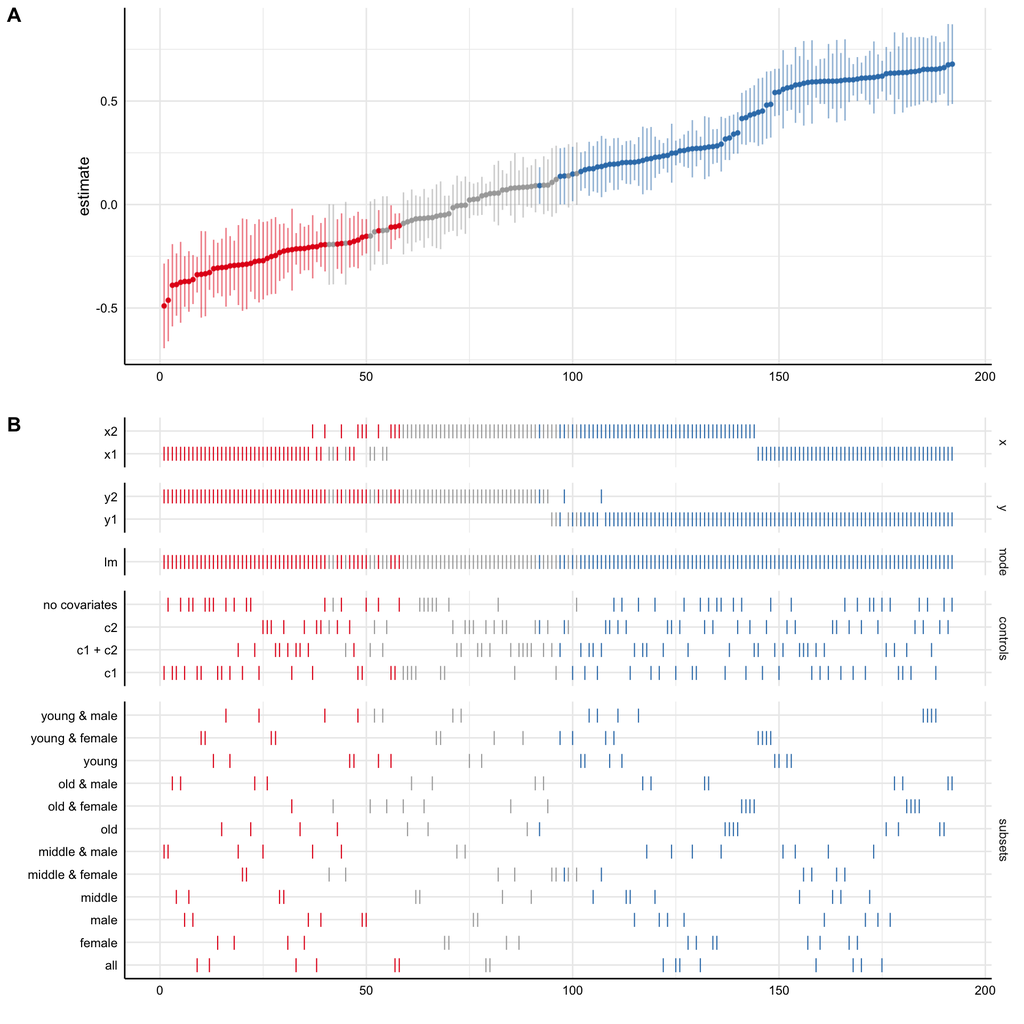

Welcome to the workshop on *Multiverse Analysis in R*. This page will be used to distribute the slides, handouts, and other materials for this course. All material is free to re-use under the [CC-BY](https://github.com/masurp/workshop_bayes/blob/main/LICENSE.md) license.

Empirical results depend on the conceptual and analytical choices made by the researcher. For example, researchers need to decide how variables should be operationalized and estimated, which variables to control for, which observations to exclude, what to do with missing values, which functional form to assume, which subgroups to analyse, what model to choose and so on. When interpreting study outcomes, we seek genuine insights into the underlying relationships under scrutiny. Achieving this goal hinges on the premise that reported analyses accurately represent the pool of valid analyses that could have been conducted – a condition frequently unmet. One issue is that published results may hinge upon arbitrary decisions made by researchers. Another concern is the inclination of researchers to favor evidence that aligns with their assumptions rather than presenting contrary evidence.

Multiverse-style methods (also known as specification curve analysis or vibration of effects) have been proposed as a possible solution to this dilemma. The idea is to estimate an effect across the entire set of possible specifications to expose the impact of hidden degrees of freedom and/or obtain robust, less biased estimates of the effect of interest. However, this does not come with potential pitfalls: if the investigated specifications are not truly arbitrary, multiverse-style analyses can produce misleading results, potentially hiding meaningful effects within a mass of poorly justified alternatives.

The workshop aims to equip participants with the knowledge to meaningfully apply multiverse/specification curve analyses to their own research. The 1-day workshop covers (1) a theoretical introduction to the concept of researcher’s degrees of freedom and the problem of undisclosed flexibility in data analyses, (2) an in-depth discussion of how multiverse approaches may help to establish better practices and more transparency in this regard, and (3) practical tutorial sessions illustrating how to use the package `specr` to conduct multiverse/specification curve analyses in R.

The workshop will be held by [Dr. Philipp K. Masur](https://www.philippmasur.de) (Vrije Universiteit Amsterdam), who is the developer of the R package `specr`. As we will run practical analyses in R, prior programming experience in R and familiarity with RStudio is an asset.

## Preparation

All materials and slides can be found on this webpage: https://masurp.github.io/workshop_specr/.

For this 1-day workshop, I expect you…

1. …to have R and RStudio installed. If you haven’t done so yet, have a look at this [getting started](https://github.com/ccs-amsterdam/r-course-material/blob/master/tutorials/R_basics_1_getting_started.md) tutorial, which walks you through the installation and helps you get some first hands-on experience using R. If possible, try to install the R package `specr`, which we will use to run multiverse analyses:

```r
install.packages("specr")
```

2. …to have some basic knowledge of R and particularly data wrangling skills (at best, some knowledge about the `tidyverse`). If this is still new to you, we have several videos and tutorials on our [R course material GitHub page](https://github.com/ccs-amsterdam/r-course-material) that can help you getting started. I would suggest to check out the tutorials on transforming, summarizing, visualizing and reshaping data in the “data wrangling with the tidyverse” category.
3. …some basic knowledge of regression models (e.g., linear regression, logistic regression, multilevel linear regression).

**Note:** The workshop will NOT provide an introduction to R!

### Morning

| Time | Topic |
| --- | --- |
| 09:00 - 09:30 | Statistical Fortune-Telling |
| 09:30 - 10:00 | A Garden of Forking Paths |
| 10:00 - 11:00 | R: Exercise I: Basic Mechanisms of Multiverse Analysis |
| 11:00 - 12:00 | Into the Multiverse |

### Afternoon

| Time | Topic |
| --- | --- |
| 13:00 - 13:45 | Arbitrary Decisions |
| 13:45 - 14:45 | R: Exercise II: Multiverse Analysis with `specr` |
| 14:45 - 15:30 | A Mass of Poorly Justified Alternatives |
| 16:00 - 16:30 | R: Exercise III: Advanced Specifications |

This course is published under the following [license](https://github.com/masurp/workshop_specr/blob/main/LICENSE).